# PCA lab

```r
library(dplyr)  # optional
library(MASS)
```

## Analysis on demographic data in EU

The dataset in `EUdemo.txt` contains a set of demographic statistics for $40$ european contries in 1999 (from the Statistical Yearbook 2002). In this study we aim at studying the relationships between the demographic variables and possibly trying to reduce data dimension.

1. Let’s upload the data, look at the structure and at the first rows, moreover, save into R objs the dimensions of data:

```r
x <- read.table(..., ..., ...)
x %>% str
x %>% ...
n <- ...
p <- ...
```

```
'data.frame':   41 obs. of  13 variables:
 $ NAT : num  9.65 11.17 12.44 11.15 12.59 ...
 $ MOR : num  9.66 10.27 11.12 9.54 9.16 ...
 $ CR.N: num  -0.0124 0.8996 1.3152 1.6068 3.4264 ...
 $ MIG : num  2.447 1.574 1.766 0.658 0.846 ...
 $ CR.T: num  2.43 2.47 3.08 2.27 4.27 ...
 $ M.IN: num  4.3 5.3 4.2 3.6 4.8 4.7 5.9 5.5 5.2 2.9 ...
 $ VEC : num  92 95 80.6 81.4 84.3 ...
 $ N.FI: num  1.32 1.61 1.73 1.74 1.77 1.36 1.3 1.88 1.22 1.73 ...
 $ E.P : num  28.1 28.5 29.6 29.6 29.3 28.6 28.7 30.5 30 29.4 ...
 $ NU  : num  4.9 4.3 6.7 4.7 4.8 5.2 5.9 4.9 4.8 4.8 ...
 $ E.M : num  27 26.1 29.7 27.7 27.6 26.9 26.5 28.2 27.6 27.4 ...
 $ V.M : num  75.1 74.8 74.2 73.8 74.9 74.5 75.4 73.9 76 74.7 ...
 $ V.F : num  81 81.1 79 81 82.4 80.5 80.4 79 82.1 81.2 ...
                NAT       MOR        CR.N       MIG     CR.T M.IN   VEC N.FI  E.P
Austria    9.650613  9.662970 -0.01235674 2.4466343 2.434278  4.3  92.0 1.32 28.1
Belgio    11.167121 10.267493  0.89962793 1.5743489 2.473977  5.3  95.0 1.61 28.5
Danimarca 12.437998 11.122802  1.31519615 1.7661205 3.081317  4.2  80.6 1.73 29.6
Finlandia 11.151013  9.544183  1.60683000 0.6582195 2.265049  3.6  81.4 1.74 29.6
Francia   12.590642  9.164214  3.42642783 0.8460316 4.272459  4.8  84.3 1.77 29.3
Germania   9.387304 10.308129 -0.92082545 2.4616247 1.540799  4.7 100.7 1.36 28.6
           NU  E.M  V.M  V.F
Austria   4.9 27.0 75.1 81.0
Belgio    4.3 26.1 74.8 81.1
Danimarca 6.7 29.7 74.2 79.0
Finlandia 4.7 27.7 73.8 81.0
Francia   4.8 27.6 74.9 82.4
Germania  5.2 26.9 74.5 80.5
```

2. Extract the names of the countries. Among them, `UE` actually represents the centroid of the “Europe of 15” (1995), corresponding to the first $15$ rows. Identify the row index of the centroid in order to exclude this row in the following analysis when opportune.

```r
x %>% ...
ind_EU <- ...
ind_EU
```

```
 [1] "Austria"           "Belgio"            "Danimarca"         "Finlandia"
 [5] "Francia"           "Germania"          "Grecia"            "Irlanda"
 [9] "Italia"            "Lussemburgo"       "Paesi Bassi"       "Portogallo"
[13] "Regno Unito"       "Spagna"            "Svezia"            "UE"
[17] "Albania"           "Bielorussia"       "Bosnia-Erzegovina" "Bulgaria"
[21] "Cipro"             "Croazia"           "Estonia"           "Islanda"
[25] "Iugoslavia "       "Lettonia"          "Lituania"          "Macedonia"
[29] "Malta"             "Moldova"           "Norvegia"          "Polonia"
[33] "Repubblica ceca"   "Romania"           "Russia"            "San Marino"
[37] "Slovacchia"        "Slovenia"          "Svizzera"          "Turchia"
[41] "Ungheria"
[1] 16
```

## Exploration

3. Let look, first, at the relationship between `V.M` and `V.F`, reading also the names of the countries.

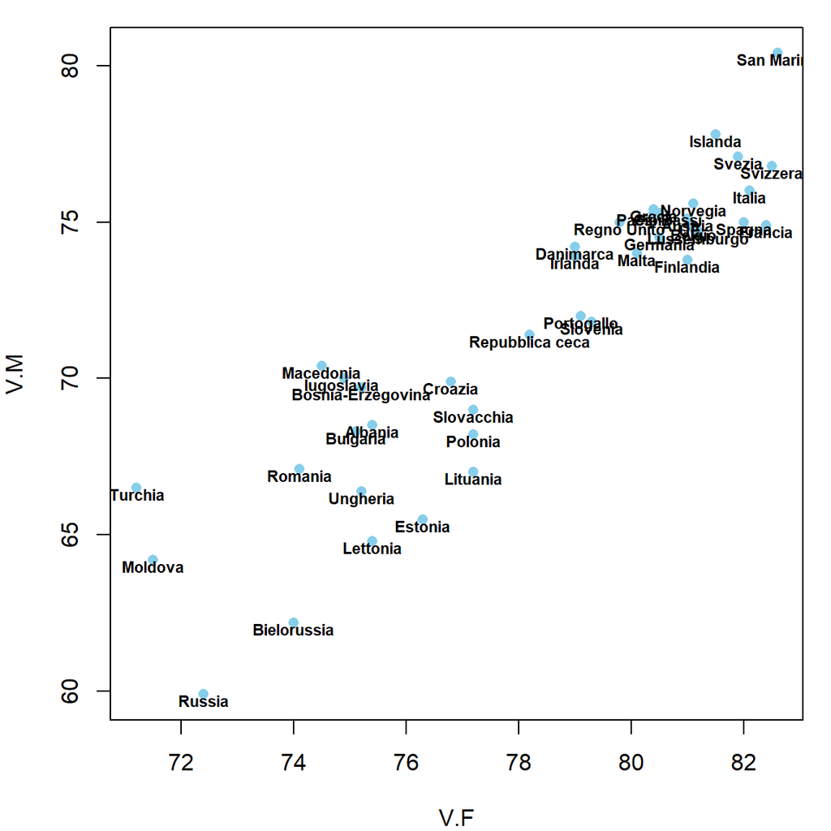

```r
attach(x)
plot(V.M ~ V.F)
text(V.M ~ V.F, ...)
detach(x)
```

Now, let investigate the relationship 2-by-2 between the all variables.

4. (When you study by your own) Try to improve on the basic command by adding either a smoothed curve, or the correlation coefs, etc..

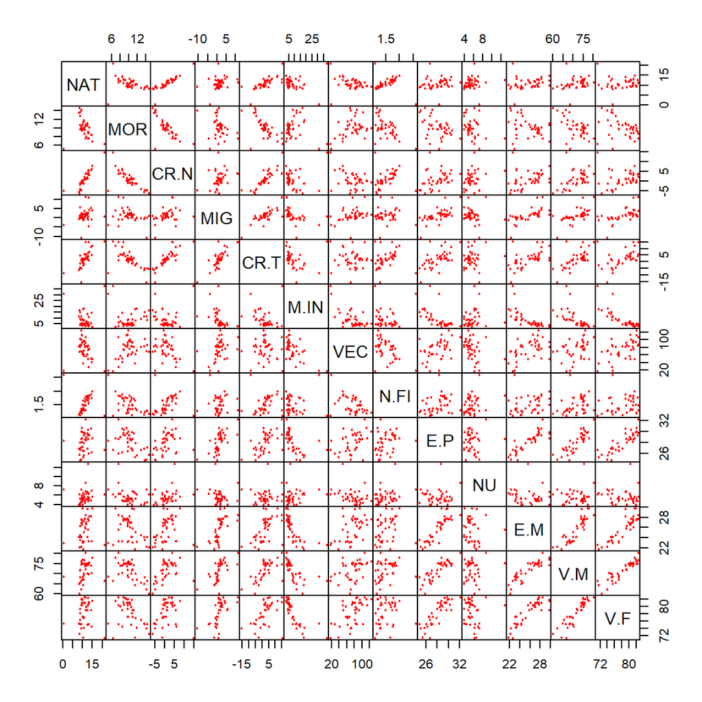

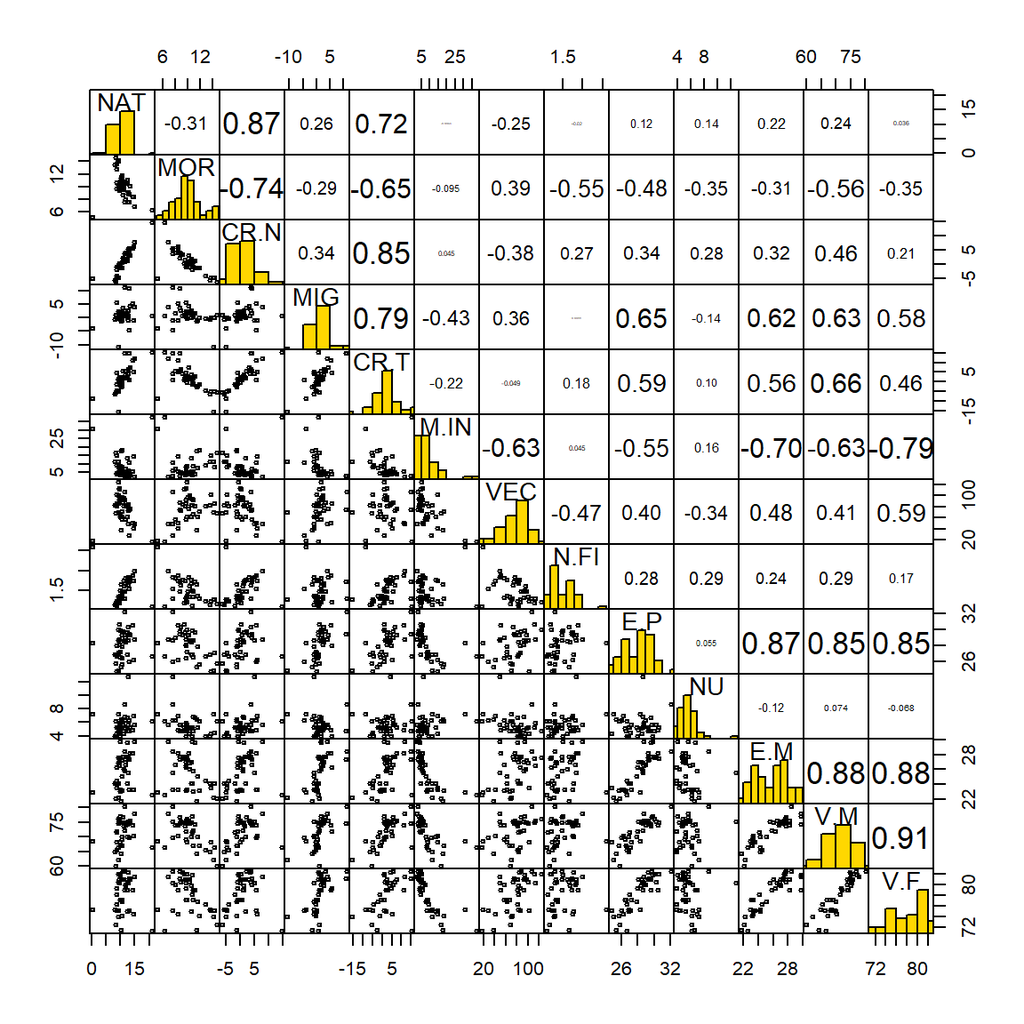

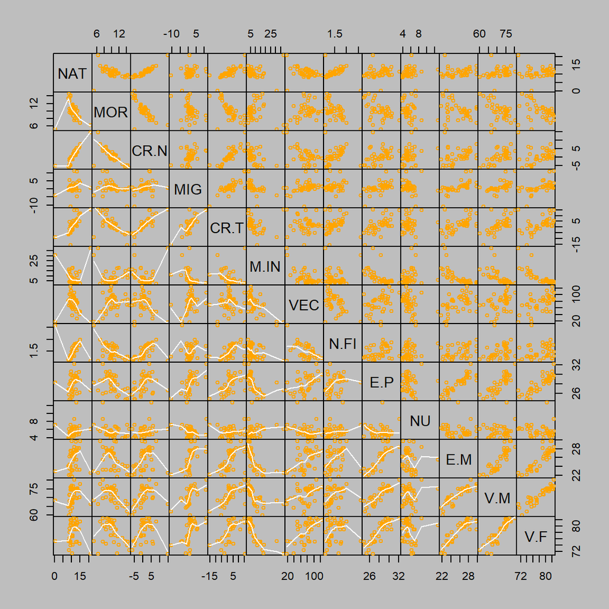

```r
pairs(x)
```

5. Now, let calculate some summary statistics: the mean vector, the covariance matrix, and the correlation matrix. For each, there are several ways to do it. Moreover, calculate the centered data matrix.

```r
# the MEAN VECTOR
m <- colMeans(x)
apply(...,...,...)
# the COVARIANCE MATRIX
S <- cov(x)
# the CORRELATION MATRIX
# cor(): compute sample correlation
R <- cor(x)
# centered x
x.cen <- scale(...,... ...)
```

```
       NAT        MOR       CR.N        MIG       CR.T       M.IN        VEC
10.8785456 10.0597582  0.8187874  1.2081583  2.0269457  8.8585366 74.5634146
      N.FI        E.P         NU        E.M        V.M        V.F
 1.5079505 28.0496634  5.6584602 25.6877812 71.6424422 78.3257844
       NAT  MOR  CR.N   MIG CR.T   M.IN    VEC N.FI  E.P    NU   E.M   V.M   V.F
NAT    8.5 -1.9  10.5   2.7 13.2   -0.1  -18.2  0.0  0.6   0.6   1.5   3.3   0.3
MOR   -1.9  4.6  -6.5  -2.2 -8.7   -1.5   20.8 -0.4 -1.8  -1.2  -1.5  -5.6  -2.4
CR.N  10.5 -6.5  17.0   4.9 21.9    1.3  -39.1  0.3  2.4   1.8   3.0   8.9   2.8
MIG    2.7 -2.2   4.9  12.7 17.6  -11.2   31.4  0.0  4.0  -0.8   5.2  10.4   6.7
CR.T  13.2 -8.7  21.9  17.6 39.5   -9.9   -7.6  0.3  6.5   1.0   8.2  19.3   9.5
M.IN  -0.1 -1.5   1.3 -11.2 -9.9   53.0 -112.9  0.1 -7.0   1.8 -11.9 -21.4 -18.9
VEC  -18.2 20.8 -39.1  31.4 -7.6 -112.9  610.8 -3.5 17.4 -13.2  27.7  47.3  47.8
N.FI   0.0 -0.4   0.3   0.0  0.3    0.1   -3.5  0.1  0.1   0.1   0.2   0.4   0.2
E.P    0.6 -1.8   2.4   4.0  6.5   -7.0   17.4  0.1  3.0   0.1   3.5   6.9   4.9
NU     0.6 -1.2   1.8  -0.8  1.0    1.8  -13.2  0.1  0.1   2.4  -0.4   0.5  -0.3
E.M    1.5 -1.5   3.0   5.2  8.2  -11.9   27.7  0.2  3.5  -0.4   5.4   9.5   6.7
V.M    3.3 -5.6   8.9  10.4 19.3  -21.4   47.3  0.4  6.9   0.5   9.5  21.7  13.8
V.F    0.3 -2.4   2.8   6.7  9.5  -18.9   47.8  0.2  4.9  -0.3   6.7  13.8  10.7
      NAT  MOR CR.N  MIG CR.T M.IN  VEC N.FI  E.P   NU  E.M  V.M  V.F
NAT   1.0 -0.3  0.9  0.3  0.7  0.0 -0.3  0.0  0.1  0.1  0.2  0.2  0.0
MOR  -0.3  1.0 -0.7 -0.3 -0.6 -0.1  0.4 -0.5 -0.5 -0.4 -0.3 -0.6 -0.3
CR.N  0.9 -0.7  1.0  0.3  0.8  0.0 -0.4  0.3  0.3  0.3  0.3  0.5  0.2
MIG   0.3 -0.3  0.3  1.0  0.8 -0.4  0.4  0.0  0.7 -0.1  0.6  0.6  0.6
CR.T  0.7 -0.6  0.8  0.8  1.0 -0.2  0.0  0.2  0.6  0.1  0.6  0.7  0.5
M.IN  0.0 -0.1  0.0 -0.4 -0.2  1.0 -0.6  0.0 -0.6  0.2 -0.7 -0.6 -0.8
VEC  -0.3  0.4 -0.4  0.4  0.0 -0.6  1.0 -0.5  0.4 -0.3  0.5  0.4  0.6
N.FI  0.0 -0.5  0.3  0.0  0.2  0.0 -0.5  1.0  0.3  0.3  0.2  0.3  0.2
E.P   0.1 -0.5  0.3  0.7  0.6 -0.6  0.4  0.3  1.0  0.1  0.9  0.9  0.9
NU    0.1 -0.4  0.3 -0.1  0.1  0.2 -0.3  0.3  0.1  1.0 -0.1  0.1 -0.1
E.M   0.2 -0.3  0.3  0.6  0.6 -0.7  0.5  0.2  0.9 -0.1  1.0  0.9  0.9
V.M   0.2 -0.6  0.5  0.6  0.7 -0.6  0.4  0.3  0.9  0.1  0.9  1.0  0.9
V.F   0.0 -0.3  0.2  0.6  0.5 -0.8  0.6  0.2  0.9 -0.1  0.9  0.9  1.0
```

## PCA

```r
help(princomp)
help(prcomp)
help(svd)
```

Note that the default calculation with `princomp` (which calls `eigen`) uses divisor ‘N’, whereas `prcomp` (which calls `svd`) uses divisor ‘N-1’.

6. Let perform a PCA analysis. Do we use $S$ or $R$?

```r
PCdemo <- prcomp(scale(x))
# or, equivalently
PCdemo2 <- princomp(covmat = cor(x))

summary(PCdemo)
Importance of components:
                          PC1    PC2    PC3     PC4     PC5    PC6    PC7     PC8
Standard deviation     2.4308 1.8014 1.2318 0.88721 0.77533 0.6440 0.5099 0.38230
Proportion of Variance 0.4545 0.2496 0.1167 0.06055 0.04624 0.0319 0.0200 0.01124
Cumulative Proportion  0.4545 0.7041 0.8209 0.88141 0.92765 0.9596 0.9796 0.99080
                           PC9    PC10    PC11      PC12      PC13
Standard deviation     0.26107 0.18410 0.13264 6.485e-08 3.162e-09
Proportion of Variance 0.00524 0.00261 0.00135 0.000e+00 0.000e+00
Cumulative Proportion  0.99604 0.99865 1.00000 1.000e+00 1.000e+00
summary(PCdemo2)
Importance of components:
                          Comp.1    Comp.2    Comp.3     Comp.4     Comp.5
Standard deviation     2.4308139 1.8013700 1.2318199 0.88721081 0.77533376
Proportion of Variance 0.4545274 0.2496103 0.1167216 0.06054946 0.04624173
Cumulative Proportion  0.4545274 0.7041377 0.8208593 0.88140875 0.92765048
                           Comp.6     Comp.7     Comp.8      Comp.9     Comp.10
Standard deviation     0.64398056 0.50993482 0.38230364 0.261069355 0.184097680
Proportion of Variance 0.03190084 0.02000258 0.01124277 0.005242862 0.002607074
Cumulative Proportion  0.95955132 0.97955390 0.99079667 0.996039537 0.998646610
                          Comp.11      Comp.12 Comp.13
Standard deviation     0.13264263 6.381537e-08       0
Proportion of Variance 0.00135339 3.132617e-16       0
Cumulative Proportion  1.00000000 1.000000e+00       1
```

7. How do we know what elements are contained in the output?

```r
...
...
```

```
[1] "sdev"     "rotation" "center"   "scale"    "x"
[1] "sdev"     "loadings" "center"   "scale"    "n.obs"    "scores"   "call"
```

The matrix of coefficients (printed the first four).

```r
PCdemo$rot
PCdemo2$load
```

```
             PC1         PC2         PC3          PC4
NAT   0.16399683  0.31588445 -0.49840174  0.179319989
MOR  -0.23628363 -0.35762844 -0.23452208  0.135411199
CR.N  0.23884821  0.40951120 -0.23195872  0.056996369
MIG   0.31273438 -0.06027224 -0.22925138 -0.222864641
CR.T  0.33376363  0.23427365 -0.28194396 -0.088921364
M.IN -0.25435056  0.32366129 -0.01737317 -0.219683021
VEC   0.13643722 -0.47822489 -0.12898179  0.195280549
N.FI  0.11232422  0.24719017  0.57211724 -0.327522380
E.P   0.36776488 -0.08219099  0.17078736 -0.009631376
NU    0.01754236  0.27909851  0.30578069  0.825497927
E.M   0.37055899 -0.14574206  0.06397082 -0.058282672
V.M   0.39081625 -0.05008280  0.12353408  0.070447653
V.F   0.35984660 -0.20771031  0.15640430  0.071543977
          Comp.1      Comp.2      Comp.3       Comp.4
NAT   0.16399683  0.31588445  0.49840174  0.179319989
MOR  -0.23628363 -0.35762844  0.23452208  0.135411199
CR.N  0.23884821  0.40951120  0.23195872  0.056996369
MIG   0.31273438 -0.06027224  0.22925138 -0.222864641
CR.T  0.33376363  0.23427365  0.28194396 -0.088921364
M.IN -0.25435056  0.32366129  0.01737317 -0.219683021
VEC   0.13643722 -0.47822489  0.12898179  0.195280549
N.FI  0.11232422  0.24719017 -0.57211724 -0.327522380
E.P   0.36776488 -0.08219099 -0.17078736 -0.009631376
NU    0.01754236  0.27909851 -0.30578069  0.825497927
E.M   0.37055899 -0.14574206 -0.06397082 -0.058282672
V.M   0.39081625 -0.05008280 -0.12353408  0.070447653
V.F   0.35984660 -0.20771031 -0.15640430  0.071543977
```

8. What does the `plot` show?

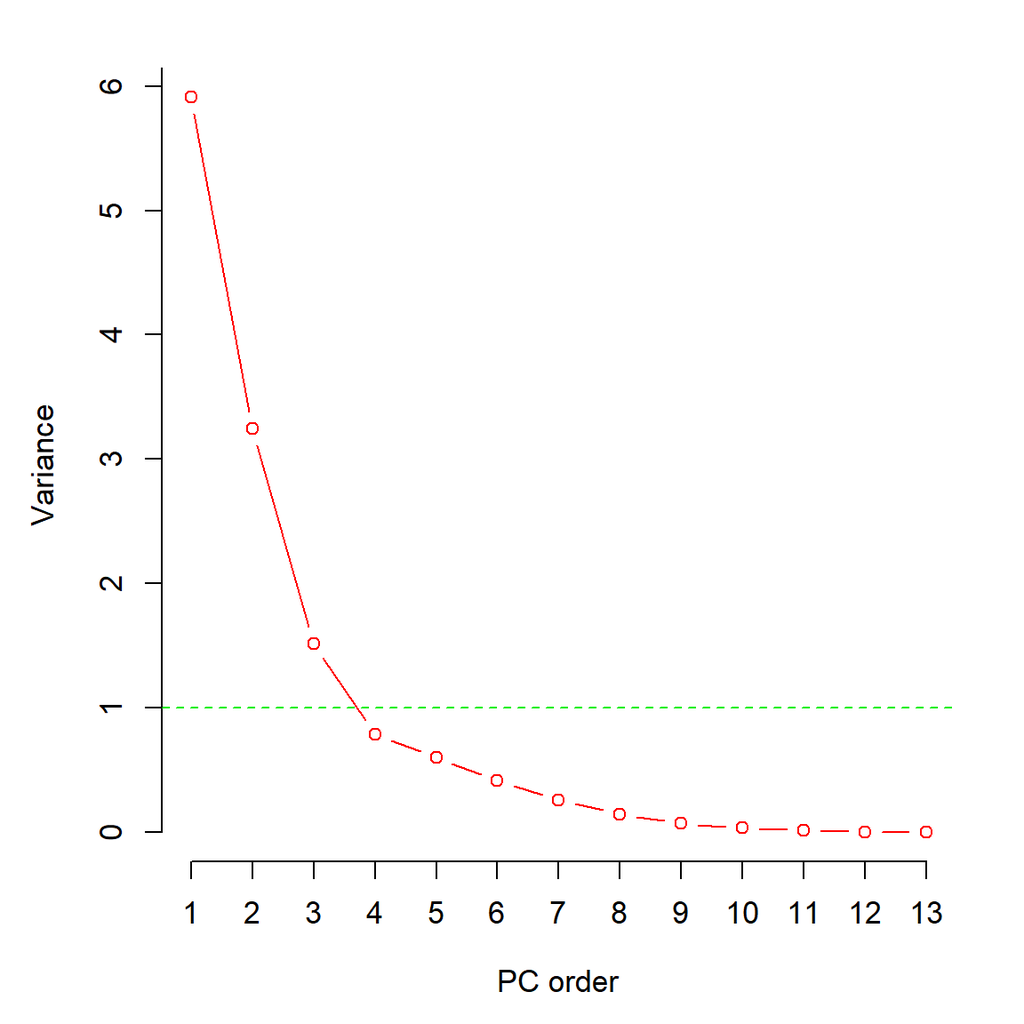

```r
plot(PCdemo)
plot(PCdemo2)
# equivalent to screeplot()
```

9. How many components do we maintain?

Now, let interpret somehow the relevant components.

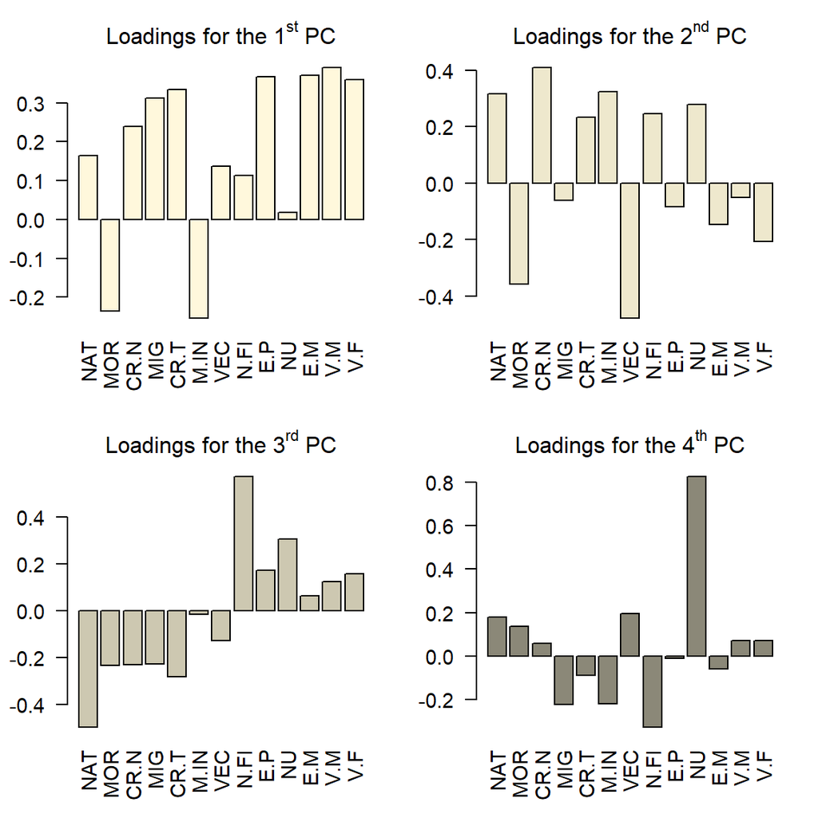

```r
barplot(PCdemo$rot[, 1])
...
...
...
```

A (slightly) more effective evaluation is obtained using the correlations between PC and $X$.

```r
corr <- PCdemo$rot[, 1:4] %*% diag(...)
```

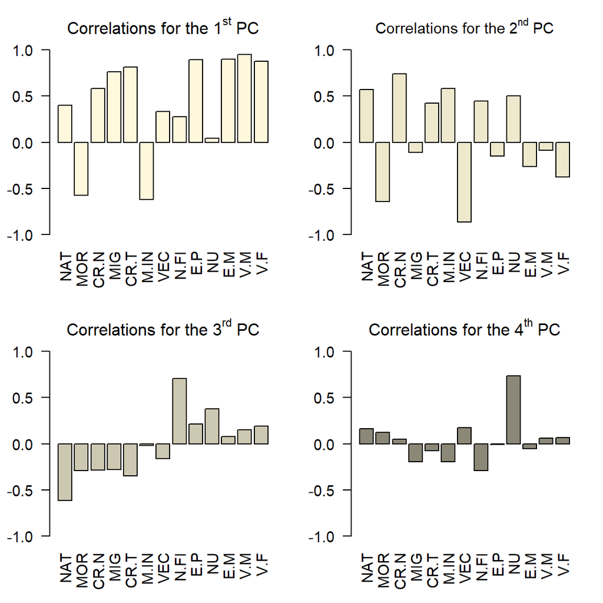

Plot of firts two PCs.

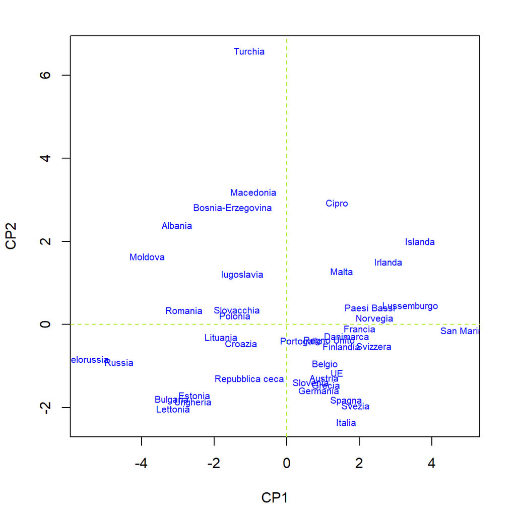

```r
plot(PCdemo$x[, 1:2])
```

Plot of third and fourth PCs. 10) Instead of using the scores directly provided by the routine try to calculate the $z$ scores by your own.

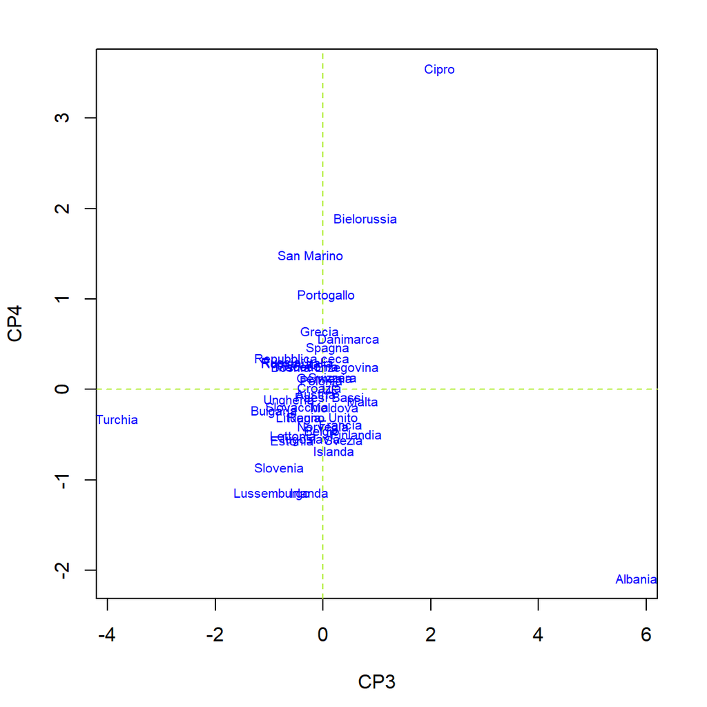

```r
plot(PCdemo$x[, 3:4])
z <- ...
```

11) Can you see the decrease of importance of last PCs from the graph?

## Biplot

Biplot is another unsupervised technique for dimensionality reduction. It performs rduction on both dimensions, on units and on variables. There are infinitive variants of biplot. We show the ones most used below.

Biplot with $\alpha=1$

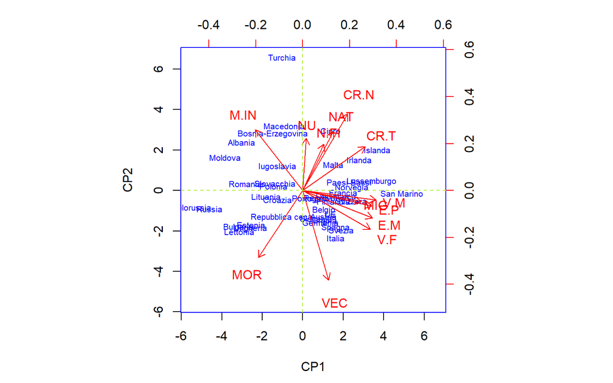

```r
biplot(z[, 1:2], loadings(CPdemo2)[, 1:2])
```

Biplot with $\alpha=0$

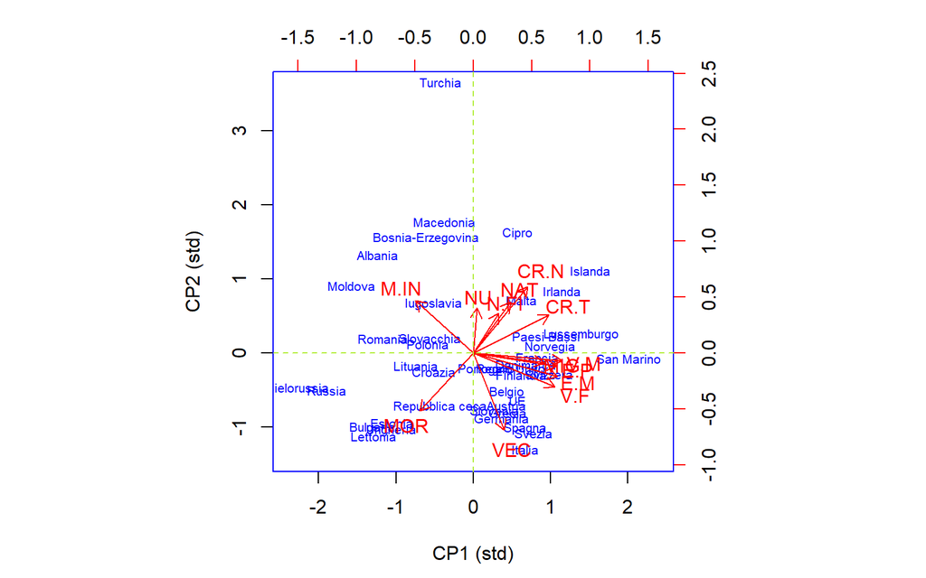

```r
z_n <- z %*% diag(1/PCdemo2$sdev)
biplot(z_n[, 1:2], corr[, 1:2])
```

```r
scale(x)["Italia", ]
       NAT        MOR       CR.N        MIG       CR.T       M.IN        VEC
-0.5338529 -0.0691234 -0.3428655  0.1547240 -0.1370699 -0.5023208  2.0205622
      N.FI        E.P         NU        E.M        V.M        V.F
-0.9527312  1.1180108 -0.5540672  0.8239170  0.9364692  1.1553177

corr["VEC", ]
[1]  0.3316535 -0.8614600 -0.1588823  0.1732550
```

Matilde Trevisani

2018-11-28